# Statistical inference with the GSS data

## Setup

### Load packages

```r
library(ggplot2)
library(dplyr)
library(statsr)
```

### Load data

Make sure your data and R Markdown files are in the same directory. When loaded your data file will be called `gss`. Delete this note when before you submit your work.

```r
load("gss.Rdata")
```

## Part 1: Data

The data set represents an observational study - national sample gathered thru face-to-face interviews about 1.5 hours long. Each survey prior to 2004 was an independently drawn sample of English-speaking persons 18 y.o. or over, living in non-institutional arrangements within the United States. Starting in 2006 Spanish-speakers were added to the target population. Block quota sampling and full probability sampling were employed in surveys of different years. The sample is a multi-stage area probability sample to the block or segment level. At the block level, however, quota sampling is used with quotas based on sex, age, and employment status. The Primary Sampling Units (PSUs) employed are Standard Metropolitan Statistical Areas (SMSAs) or non-metropolitan counties selected in NORC’s Master Sample. These SMSAs and counties were stratified by region, age, and race before selection. The chance of non-response bias was considered, so the interviewers are given instructions to canvass and interview only after 3:00 p.m. on weekdays or during the weekend or holidays. This type of sample design is most appropriate when the past experience and judgment of a project director suggest that sample biases are likely to be small relative to the precision of the measuring instrument and the decisions that are to be made. In addition to that, the `weighting` methods were applied, the GSS contains several weight variables (ADULTS, OVERSAMP, FORMWT, WTSSNR, WTSSALL) that users should use as needed as well as weight-related variables (ISSP+PHASE). Taking in the consideration all of the above (random sampling/clustering, blocking, stratifying, weighting, multi-stage probability sample, the bias is taken into account) we can state that the study is generalizable to the English- and Spanish-speaking population of the US over 18 y.o. Because of the observational nature of the study, no random assignment was done so we can not conclude causality.

## Part 2: Research question

Does there appear to be a relationship between time spent in front of TV and job satisfaction level?

The question is of interest for author because he is interested in exploring how TV might potentually affect the other aspects of person’s life. The author undestands that it is not possible to infer causation in the current study settings, so he only tries to find a relation between groups to understand if further analysis worths to be invested into.

## Part 3: Exploratory data analysis

Let’s start with analyzing the hours spent in front of TV. Using summary statistics and visualization, let’s describe the distribution of TV hours:

```r
summary(gss$tvhours)
```

```
##    Min. 1st Qu.  Median    Mean 3rd Qu.    Max.    NA's
##   0.000   2.000   2.000   2.971   4.000  24.000   23206
```

From the summary statistics we can see that the distribution is slightly right-skewed (because the `median` is smaller than the `mean`), also we can witness that there is a natural boundary around `0` because watching negative number of hours does not make sense, hence we have the boundary at 0 with a long tail up to 24 hours period.

Let’s visualize the data:

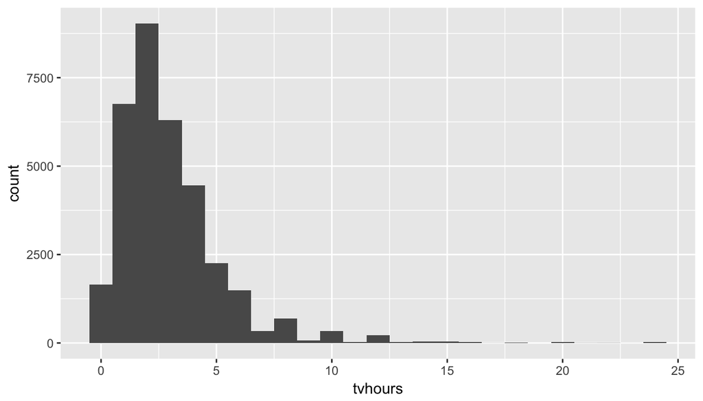

```r
ggplot(gss, aes(x = tvhours)) + geom_histogram(binwidth = 1)
```

```r
tvData <- gss %>% filter(!is.na(tvhours))

tvData <- tvData %>% mutate(tvhours7 = ifelse(tvhours == 0, '0 not watching',
                                              ifelse(tvhours >= 1 & tvhours <= 2, '1 some time',
                                                     ifelse(tvhours >= 3 & tvhours <= 4, '2 watching',
                                                        ifelse(tvhours >= 5 & tvhours <= 8, '3 watching a lot',
                                                            ifelse(tvhours >= 9 & tvhours <= 24, '4 all time', 'error')
                                                     )
                                              )
                                      )
                            )
)

tvData %>% group_by(tvhours7) %>% summarize(n = n())
```

```
## # A tibble: 5 x 2
##           tvhours7     n
##              <chr> <int>
## 1   0 not watching  1657
## 2      1 some time 15786
## 3       2 watching 10753
## 4 3 watching a lot  4762
## 5       4 all time   897
```

Let’s explore the second variable in the same fashion, since the observations that have `NA` for TV hours spent are useless for our study, we will use the `tvData` data which we have had recently created. We will explore the `satjob` variable:

```r
summary(tvData$satjob)
```

```
##    Very Satisfied    Mod. Satisfied   A Little Dissat Very Dissatisfied
##             12667             10272              2638              1097
##              NA's
##              7181
```

We can see that this is an ordinal categorical variable with `4` levels. A lot of observations have `NA` values, since they are not helpful for our needs, first, let’s just filter them out:

```r
tvData <- tvData %>% filter(!is.na(satjob))

summary(tvData$satjob)
```

```
##    Very Satisfied    Mod. Satisfied   A Little Dissat Very Dissatisfied
##             12667             10272              2638              1097
```

Now let’s see the distributions of the categories:

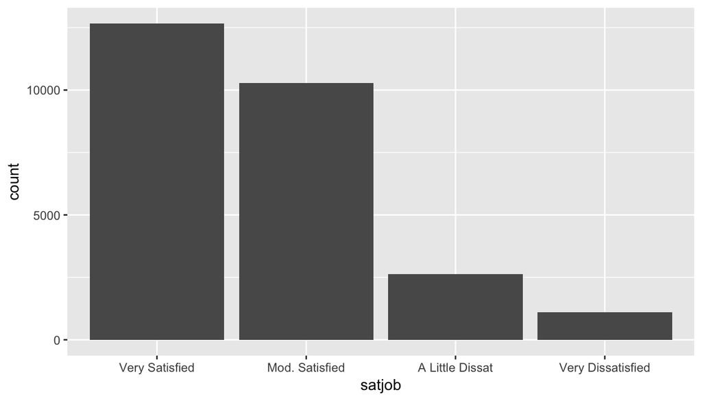

```r
ggplot(tvData, aes(x = satjob)) + geom_bar()
```

We can see that the most people are satisfied with their jobs, the people that are dissatisfied with their jobs take less than 1/4 of the observations.

Let’s transform the data to have only two levels of satisfaction for the convenience sake:

```r
tvData <- tvData %>% mutate(satjob2 = ifelse(satjob == 'Very Satisfied' | satjob == 'Mod. Satisfied', 'Satisfied', 'Not satisfied'))

tvData %>% group_by(satjob2) %>% summarize(n = n())
```

```
## # A tibble: 2 x 2
##         satjob2     n
##           <chr> <int>
## 1 Not satisfied  3735
## 2     Satisfied 22939
```

Now let’s see the two variables on one scale, first let’s build a `contingency table`:

```r
contincency <- table(tvData$satjob2, tvData$tvhours7)
contincency <- addmargins(contincency, 1)
contincency <- addmargins(contincency, 2)
print(contincency)
```

```
##
##                 0 not watching 1 some time 2 watching 3 watching a lot
##   Not satisfied            205        1677       1167              564
##   Satisfied               1176       11701       7017             2598
##   Sum                     1381       13378       8184             3162
##
##                 4 all time   Sum
##   Not satisfied        122  3735
##   Satisfied            447 22939
##   Sum                  569 26674
```

At the first glimpse we see that the data varies across the categories, let’s build a stardintized barplot to try to catch the different in the categories proportions:

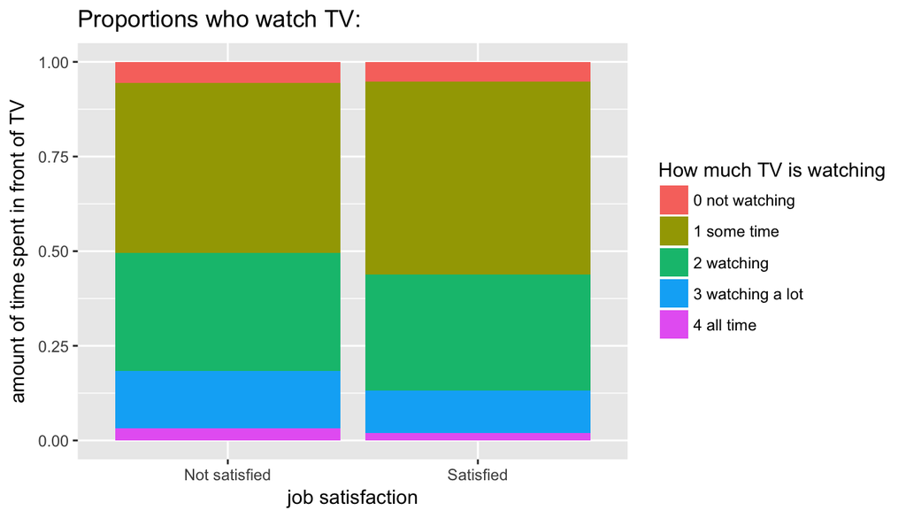

```r
ggplot(data = tvData, aes(x = satjob2, fill = tvhours7)) + geom_bar(position = "fill") +
  labs(title="Proportions who watch TV:") +
  xlab("job satisfaction") +
  ylab("amount of time spent in front of TV") +
  scale_fill_discrete(name = "How much TV is watching")
```

As we can see from the standartized barplot for levels proportions, the levels of `1 some time` and `3 watching a lot` have the most variation among the satisfaction levels. For the `1 some time` it is somewhat larger for the `Satisfied` level and is larger, at the same time the proportion of `3 watching a lot` is smaller for the `Satisfied` level and larger for the `Not satisfied` level. So our prior assumtion about the relation between the categories overall holds, so we can invest further into statistical inference methods to understand if this data provide a `statistically significant` evidence that for the relation between the categories.

## Part 4: Inference

Let’s do the inference, as we remember from the original research questions, we are interested if there appear to be a relationship between time spent in front of TV and job satisfaction level? Just finding a difference among the levels(and not knowing which levels exactly are different) is sufficient for our needs hence we can pick the `Chi-square independence` test to proceed. The test commonly used to determine whether there is a significant association between some two variables - exactly what we need here.

### First, let’s state out hypotheses.

H0: Amount of TV watched per day and job satisfaction are independent, TV watching time habits job do not vary by job satisfaction.

Ha: Amount of TV watched per day and job satisfaction are dependent, TV watching time habits do vary by job satisfaction.

The `chi-square test of independence` in the nushell is:

- quantify how different the observed counts are from the expected counts
- large deviations from what would be expected on sampling variation(chance) alone provide strong evidence for the alternative hypothesis
- called independence test since we evaluate relationship between two categorical variables

### Now, let’s check the conditions needed for the chi-square test of independence

1. Independence
- random sample - the random sampling techniques applied while data collected (random sampling/clustering, stratifying,multi-stage probability sampling, see Part1 fro more details)
- sampling without replacement, and sample size of 57061 is much smaller than 10% of the entire population
- each case contributes only to one cell in the contingency table - there is no human can watch tv 2 hours and 0 hours per day on average simultaneously, same for the job satisfaction levels as they are mutually exclusive too.
2. Sample size/skew
- at least 5 expected cases for each cell

To test the last `condition` (at least 5 expected cases for each cell) let’s estimate the number of expected counts for each cell of the contincency table, as we remember, the folmula is `((total # in column) * (total # in row)) / (total #)`

```r
nRows <- nrow(contincency)
nColumns <- ncol(contincency)
total <- contincency[nRows, nColumns]

contincencyExpected <- contincency[1:nRows, 1:nColumns]

for (i in 1:(nRows-1)) {
  for (j in 1:(nColumns-1)) {
    cell <- contincency[i, j]
    rowTotal = contincency[nRows, j]
    columnTotal = contincency[i, nColumns]
    contincencyExpected[i, j] <- round((rowTotal * columnTotal) / total)
  }
}

print(contincency)
```

```
##
##                 0 not watching 1 some time 2 watching 3 watching a lot
##   Not satisfied            205        1677       1167              564
##   Satisfied               1176       11701       7017             2598
##   Sum                     1381       13378       8184             3162
##
##                 4 all time   Sum
##   Not satisfied        122  3735
##   Satisfied            447 22939
##   Sum                  569 26674
```

```r
print(contincencyExpected)
```

```
##
##                 0 not watching 1 some time 2 watching 3 watching a lot
##   Not satisfied            193        1873       1146              443
##   Satisfied               1188       11505       7038             2719
##   Sum                     1381       13378       8184             3162
##
##                 4 all time   Sum
##   Not satisfied         80  3735
##   Satisfied            489 22939
##   Sum                  569 26674
```

Having the `observed` and `expected` tables allows us to calculate the `Xsqaured` score, the formular is:

```
Xsquared = Sum( (O[i] - E[i])^2 / E[i] )
df = (# of rows - 1) * (# of columns - 1)
```

Let’s calculate the values:

```r
df = ((nRows - 1) - 1) * ((nColumns - 1) - 1)

XSquared = 0
for (i in 1:(nRows-1)) {
  for (j in 1:(nColumns-1)) {
    cellO <- contincency[i, j]
    cellE <- contincencyExpected[i, j]
    XSquared = XSquared + (((cellO - cellE)^2) / cellE)
  }
}

print(df)
```

```
## [1] 4
```

```r
print(XSquared)
```

```
## [1] 89.25601
```

Finally we can calculate the `p-value`:

```r
p <- pchisq(XSquared, df = df, lower.tail = FALSE)
print(p)
```

```
## [1] 1.894679e-18
```

With such a small `p-value` we will `reject the null-hypothesis` and conclude that the data provides significant evidence that indeed the TV watching time habits and job satisfaction are associated.

As a sanity check, let’s leverage the `inference` function and see if gives us the same results, for that we will use the `chisq.test` function and pass new contingency table without margins into it:

```r
chisq.test(table(tvData$satjob2, tvData$tvhours7))
```

```
##
##  Pearson's Chi-squared test
##
## data:  table(tvData$satjob2, tvData$tvhours7)
## X-squared = 89.922, df = 4, p-value < 2.2e-16
```

As we can see the test statistics and all other parameters are almost equal to what we had, so it converged to the same results. Remember that this is an observational study so no causal relation can be inferred based on this, we can only say about the variables relation here.

1. Independence
- Within groups
  - random sampling indeed
  - sampling without replacing, < 10% of the entire population
- Between groups - the observations are independent between groups - we assume that the TV watching habits and job satisfaction is independent among the people in the sample
2. Sample size/skew (we will have to check it further upon computation):
- `n1*p1 >= 10 and n1 * (1 - p1) >= 10`
- `n2*p2 >= 10 and n2 * (1 - p2) >= 10`

We will need to create the confidence intervals for the difference of two proportions, followed up with the hypothesis testing to see if the methods agree:

For each groups comparations we will have the same Hypotheses:

H0: p1 = p2 # the true population parameter is the same among groups Ha: p1 != p2 # the true population parameter is NOT the same among groups

So let’s write a function that will take the contingency table and two indecies, and to the inference for us:

```r
compareTwoProportionsCI = function(contingencyTable, i1, i2) {
  # get the columns
  column1 = contingencyTable[1:2, i1]
  column2 = contingencyTable[1:2, i2]
  col1 = as.vector(column1)
  col2 = as.vector(column2)
  # first, let's compute the proportions for the observed data
  total1 = sum(col1[1:length(col1)])
  total2 = sum(col2[1:length(col2)])
  phat1 = col1[length(col1)] / total1
  phat2 = col2[length(col2)] / total2
  # check the # of observations conditions
  condition1 = (total1 * phat1 < 10) | (total1 * (1 - phat1) < 10)
  condition2 = (total2 * phat2 < 10) | (total2 * (1 - phat2) < 10)
  if (condition1 | condition2) {
    return(print("# of observations condition is met"))
  }

  # calculate SE
  SE = sqrt( ((phat1 * (1 - phat1)) / total1) + ((phat2 * (1 - phat2)) / total2))

  # 95% CI
  Z  = 1.96
  ME = (Z * SE)
  CIlower = (phat1 - phat2) - ME
  CIupper = (phat1 - phat2) + ME

  if ((CIlower > 0 & CIupper > 0) | (CIlower < 0 & CIupper < 0)) {
    cat("\n✔ Statisticly significant difference in proportions: ", "we'd reject the null hypoothesis CI(", CIlower, ", ", CIupper, ")", " SE: ", SE, sep = "" )
  } else {
    cat("\n⊗ Not a statisticly significant difference in proportions: ", "we'd not reject the null hypoothesis CI(", CIlower, ", ", CIupper, ")", " SE: ", SE, sep = "" )
  }
}

compareTwoProportionsHT = function(contingencyTable, i1, i2) {
  # get the columns
  column1 = contingencyTable[1:2, i1]
  column2 = contingencyTable[1:2, i2]

  col1 = as.vector(column1)
  col2 = as.vector(column2)
  # first, let's compute the proportions for the observed data
  total1 = sum(col1[1:length(col1)])
  total2 = sum(col2[1:length(col2)])
  # proportion estimates calculations
  phat_pool = sum(contingencyTable[2, 1:(ncol(contincency)-1)]) / sum(contingencyTable)
  phat1 = col1[length(col1)] / total1
  phat2 = col2[length(col2)] / total2

  # check the # of observations conditions
  condition1 = (total1 * phat_pool < 10) | (total1 * (1 - phat_pool) < 10)
  condition2 = (total2 * phat_pool < 10) | (total2 * (1 - phat_pool) < 10)
  if (condition1 | condition2) {
    return(print("[hypothesis test]: # of observations condition is met"))
  }

  SE = sqrt( ((phat_pool * (1 - phat_pool)) / total1) + ((phat_pool * (1 - phat_pool)) / total2) )
  Z = (phat1 - phat2) / SE
  pvalue = 2 * (1 - pnorm(abs(Z)))

  if (pvalue < .05) {
    cat("\n✔ [hypothesis test] Statisticly significant difference in proportions: ", "we'd reject the null hypoothesis pvalue = ", pvalue, " SE: ", SE, sep = "" )
  } else {
    cat("\n⊗ [hypothesis test] Statisticly significant difference in proportions: ", "we'd not reject the null hypoothesis pvalue = ", pvalue, " SE: ", SE, sep = "" )
  }
}



contingency = table(tvData$satjob2, tvData$tvhours7)
print(contingency)
```

```
##
##                 0 not watching 1 some time 2 watching 3 watching a lot
##   Not satisfied            205        1677       1167              564
##   Satisfied               1176       11701       7017             2598
##
##                 4 all time
##   Not satisfied        122
##   Satisfied            447
```

```r
# Loop thru all pairs and gen CI and p-value
nColumns <- ncol(contingency)
k = 1
for (i in k:(nColumns-2)) {
  for (j in (k+1):(nColumns-1)) {
    writeLines("\n-=-=-=-=-=-=-=-=-=-=-=-")
    columnNames = colnames(contingency)
    cat("Comparing two proporiotns: '", columnNames[i], "' and '",  columnNames[j], "' ", sep = "")
    compareTwoProportionsCI(contingency, i, j)
    compareTwoProportionsHT(contingency, i, j)
  }
  k = k + 1
}
```

```
##
## -=-=-=-=-=-=-=-=-=-=-=-
## Comparing two proporiotns: '0 not watching' and '1 some time'
## ✔ Statisticly significant difference in proportions: we'd reject the null hypoothesis CI(-0.04266154, -0.003514658) SE: 0.009986448
## ✔ [hypothesis test] Statisticly significant difference in proportions: we'd reject the null hypoothesis pvalue = 0.01857227 SE: 0.009807999
## -=-=-=-=-=-=-=-=-=-=-=-
## Comparing two proporiotns: '0 not watching' and '2 watching'
## ⊗ Not a statisticly significant difference in proportions: we'd not reject the null hypoothesis CI(-0.02607222, 0.01437653) SE: 0.01031856
## ⊗ [hypothesis test] Statisticly significant difference in proportions: we'd not reject the null hypoothesis pvalue = 0.5623999 SE: 0.01009502
## -=-=-=-=-=-=-=-=-=-=-=-
## Comparing two proporiotns: '0 not watching' and '3 watching a lot'
## ✔ Statisticly significant difference in proportions: we'd reject the null hypoothesis CI(0.006910049, 0.05293988) SE: 0.0117423
## ✔ [hypothesis test] Statisticly significant difference in proportions: we'd reject the null hypoothesis pvalue = 0.007504298 SE: 0.01119278
## -=-=-=-=-=-=-=-=-=-=-=-
## Comparing two proporiotns: '1 some time' and '2 watching'
## ✔ Statisticly significant difference in proportions: we'd reject the null hypoothesis CI(0.007812919, 0.02666758) SE: 0.004809862
## ✔ [hypothesis test] Statisticly significant difference in proportions: we'd reject the null hypoothesis pvalue = 0.0003997599 SE: 0.004869793
## -=-=-=-=-=-=-=-=-=-=-=-
## Comparing two proporiotns: '1 some time' and '3 watching a lot'
## ✔ Statisticly significant difference in proportions: we'd reject the null hypoothesis CI(0.03853772, 0.0674884) SE: 0.007385378
## ✔ [hypothesis test] Statisticly significant difference in proportions: we'd reject the null hypoothesis pvalue = 1.110223e-14 SE: 0.006861762
## -=-=-=-=-=-=-=-=-=-=-=-
## Comparing two proporiotns: '2 watching' and '3 watching a lot'
## ✔ Statisticly significant difference in proportions: we'd reject the null hypoothesis CI(0.02042872, 0.05111691) SE: 0.007828621
## ✔ [hypothesis test] Statisticly significant difference in proportions: we'd reject the null hypoothesis pvalue = 8.512271e-07 SE: 0.007266111
```

As we can see from the results of running the function on each pair, we were able to find the significant evidence in difference of population proportions in all but 1 pair ( ‘0 not watching’ <-> ‘2 watching’). Also the `confidence intervals` and `hypothesis tests` results agreed on results in all cases.

### Recap

We conducted the statistical inference in the context the question of interest: “Does there appear to be a relationship between time spent in front of TV and job satisfaction level?”. We used the `chi-square test of independence` as we wanted to find an association between two variables one of which contain more than two levels. We have found a statistically significant difference in proportions and concluded dependence. After that, we looked closer on the data to find what levels exactly do have statistically significant difference and found out that the majority of the groups do have the difference.